# Model selection with the Housing dataset

The dataset Housing from the R package Ecdat contains sales prices of houses in the city of Windsor, Canada in 1987, with n = 546. Eleven variables were observed about various aspects about the houses, including the size of a property, the number of bedrooms/bathrooms and so forth; details of the explanatory variables can be found in help(Housing).

```r
#install.packages("Ecdat")
library(Ecdat) #access Ecdat
data(Housing)
head(Housing)
```

|  | price | lotsize | bedrooms | bathrms | stories | driveway | recroom | fullbase | gashw | airco | garagepl | prefarea |
| --- | --- | --- | --- | --- | --- | --- | --- | --- | --- | --- | --- | --- |
| 1 | 42000 | 5850 | 3 | 1 | 2 | yes | no | yes | no | no | 1 | no |
| 2 | 38500 | 4000 | 2 | 1 | 1 | yes | no | no | no | no | 0 | no |
| 3 | 49500 | 3060 | 3 | 1 | 1 | yes | no | no | no | no | 0 | no |
| 4 | 60500 | 6650 | 3 | 1 | 2 | yes | yes | no | no | no | 0 | no |
| 5 | 61000 | 6360 | 2 | 1 | 1 | yes | no | no | no | no | 0 | no |
| 6 | 66000 | 4160 | 3 | 1 | 1 | yes | yes | yes | no | yes | 0 | no |

When the number of candidate variables q is small, it may be possible to fit all 2^q, q=11, submodels and select the one that meets your chosen criterion. The function regsubsets in the package leaps implements regression subset selection and allows one to view the ranked models according to different scoring criteria by plotting the results of regsubsets.

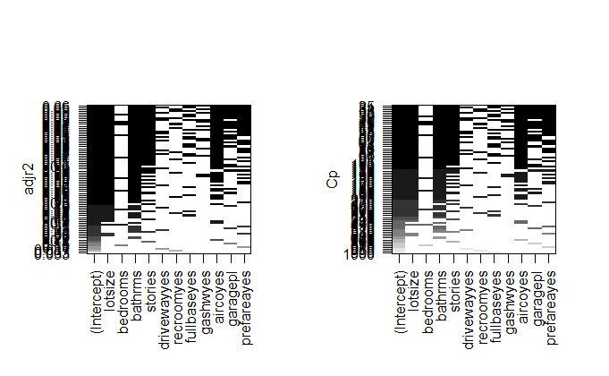

```r
#install.packages("leaps")
library(leaps)
subset.fit <- regsubsets(price ~ ., data = Housing, nbest = 10) #fit all possible models for price
#nbest specifies the number of models to be shown for each number of parameters -e.g the amount of models to consider for p=3
par(mfrow = c(1, 2)) #set graphic scale
plot(subset.fit, scale = 'adjr2') #plot results against adjusted R^2
plot(subset.fit, scale = 'Cp') #plot results against Mallow's Cp
```

According to both criteria, the model containing lotsize, bathrms, stories, fullbase, gashw, airco, garagepl and prefarea are selected.

The exhaustive search performed by regsubsets becomes quickly impossible with increasing q. The step function in the package MASS automates the process of backward, forward, or backward-forward selection based on AIC. To perform forward selection, we need to specify a starting model and the range of models which we want to examine in the search. The following code tells R to start with the null model and search through models lying in the range between the null and full models using the forward selection algorithm.

```r
library(MASS)
null <- lm(price ~ 1, data = Housing) #specify null model
full <- lm(price ~ ., data = Housing) #specify full model
step(null, scope = list(lower = null, upper = full), direction = "forward") #conduct forward selection
```

```
Start:  AIC=11131.23
price ~ 1

           Df  Sum of Sq        RSS   AIC
+ lotsize   1 1.1156e+11 2.7704e+11 10948
+ bathrms   1 1.0376e+11 2.8485e+11 10964
+ airco     1 7.9867e+10 3.0874e+11 11008
+ stories   1 6.8939e+10 3.1966e+11 11027
+ garagepl  1 5.7094e+10 3.3151e+11 11046
+ bedrooms  1 5.2183e+10 3.3642e+11 11054
+ prefarea  1 4.2082e+10 3.4652e+11 11071
+ driveway  1 3.4317e+10 3.5429e+11 11083
+ recroom   1 2.5261e+10 3.6334e+11 11096
+ fullbase  1 1.3476e+10 3.7513e+11 11114
+ gashw     1 3.3492e+09 3.8525e+11 11128
<none>                   3.8860e+11 11131

Step:  AIC=10948.47
price ~ lotsize

           Df  Sum of Sq        RSS   AIC
+ bathrms   1 6.8826e+10 2.0822e+11 10794
+ stories   1 5.5432e+10 2.2161e+11 10829
+ airco     1 4.5737e+10 2.3131e+11 10852
+ bedrooms  1 3.2329e+10 2.4472e+11 10883
+ prefarea  1 1.6995e+10 2.6005e+11 10916
+ garagepl  1 1.6746e+10 2.6030e+11 10916
+ recroom   1 1.2811e+10 2.6423e+11 10925
+ fullbase  1 1.0067e+10 2.6698e+11 10930
+ driveway  1 8.6019e+09 2.6844e+11 10933
+ gashw     1 3.7147e+09 2.7333e+11 10943
<none>                   2.7704e+11 10948

Step:  AIC=10794.54
price ~ lotsize + bathrms

           Df  Sum of Sq        RSS   AIC
+ airco     1 3.1289e+10 1.7693e+11 10708
+ stories   1 2.5927e+10 1.8229e+11 10724
+ prefarea  1 1.5699e+10 1.9252e+11 10754
```

[output cut: 96 more lines]

```
Step:  AIC=10542.71
price ~ lotsize + bathrms + airco + stories + prefarea + garagepl +
    fullbase + gashw + driveway + recroom + bedrooms


Call:
lm(formula = price ~ lotsize + bathrms + airco + stories + prefarea +
    garagepl + fullbase + gashw + driveway + recroom + bedrooms,
    data = Housing)

Coefficients:
(Intercept)      lotsize      bathrms     aircoyes      stories  prefareayes
  -4038.350        3.546    14335.558    12632.890     6556.946     9369.513
   garagepl  fullbaseyes     gashwyes  drivewayyes   recroomyes     bedrooms
   4244.829     5452.386    12831.406     6687.779     4511.284     1832.003
```

According to this procedure, the best model is the one that includes all eleven variables. We can perform backward elimination or stepwise regression on the same data set using the commands:

```r
step(full, data=Housing, direction = "backward") #conduct backward selection
```

```
Start:  AIC=10542.71
price ~ lotsize + bedrooms + bathrms + stories + driveway + recroom +
    fullbase + gashw + airco + garagepl + prefarea

           Df  Sum of Sq        RSS   AIC
<none>                   1.2703e+11 10543
- bedrooms  1 7.2829e+08 1.2775e+11 10544
- recroom   1 1.3411e+09 1.2837e+11 10546
- driveway  1 2.5434e+09 1.2957e+11 10552
- fullbase  1 2.8042e+09 1.2983e+11 10553
- gashw     1 3.7830e+09 1.3081e+11 10557
- garagepl  1 6.0666e+09 1.3309e+11 10566
- prefarea  1 7.4959e+09 1.3452e+11 10572
- stories   1 1.1945e+10 1.3897e+11 10590
- airco     1 1.5699e+10 1.4272e+11 10604
- bathrms   1 2.2022e+10 1.4905e+11 10628
- lotsize   1 2.4379e+10 1.5140e+11 10637

Call:
lm(formula = price ~ lotsize + bedrooms + bathrms + stories +
    driveway + recroom + fullbase + gashw + airco + garagepl +
    prefarea, data = Housing)

Coefficients:
(Intercept)      lotsize     bedrooms      bathrms      stories  drivewayyes
  -4038.350        3.546     1832.003    14335.558     6556.946     6687.779
 recroomyes  fullbaseyes     gashwyes     aircoyes     garagepl  prefareayes
   4511.284     5452.386    12831.406    12632.890     4244.829     9369.513
```

```r
step(full, scope=list(lower = null), data=Housing, direction = "both") #conduct forward-backward selection
```

```
Start:  AIC=10542.71
price ~ lotsize + bedrooms + bathrms + stories + driveway + recroom +
    fullbase + gashw + airco + garagepl + prefarea

           Df  Sum of Sq        RSS   AIC
<none>                   1.2703e+11 10543
- bedrooms  1 7.2829e+08 1.2775e+11 10544
- recroom   1 1.3411e+09 1.2837e+11 10546
- driveway  1 2.5434e+09 1.2957e+11 10552
- fullbase  1 2.8042e+09 1.2983e+11 10553
- gashw     1 3.7830e+09 1.3081e+11 10557
- garagepl  1 6.0666e+09 1.3309e+11 10566
- prefarea  1 7.4959e+09 1.3452e+11 10572
- stories   1 1.1945e+10 1.3897e+11 10590
- airco     1 1.5699e+10 1.4272e+11 10604
- bathrms   1 2.2022e+10 1.4905e+11 10628
- lotsize   1 2.4379e+10 1.5140e+11 10637

Call:
lm(formula = price ~ lotsize + bedrooms + bathrms + stories +
    driveway + recroom + fullbase + gashw + airco + garagepl +
    prefarea, data = Housing)

Coefficients:
(Intercept)      lotsize     bedrooms      bathrms      stories  drivewayyes
  -4038.350        3.546     1832.003    14335.558     6556.946     6687.779
 recroomyes  fullbaseyes     gashwyes     aircoyes     garagepl  prefareayes
   4511.284     5452.386    12831.406    12632.890     4244.829     9369.513
```

These give equivalent results to forward selection.